# Hurricane Fatalities

Learning Curve

9/23/2018

Some simple EDA to know more about the damage caused by these hurricanes.

```
## # A tibble: 6 x 14
##   Name  Damage_billions  Year Classification Loc1  Loc2  Loc3  Loc4  Loc5
##   <chr>           <dbl> <int> <chr>          <chr> <chr> <chr> <chr> <chr>
## 1 Harv…           125    2017 Category 4 hu… Texas Loui… Sout… Cent… The …
## 2 Maria            91.6  2017 Category 5 hu… Puer… Less… Grea… Cari… East…
## 3 Irma             64.8  2017 Category 5 hu… Less… Grea… Cari… East… <NA>
## 4 Matt…            15.1  2016 Category 5 hu… Colo… Vene… The … Unit… <NA>
## 5 Ingr…             1.5  2013 Category 1 hu… Mexi… <NA>  <NA>  <NA>  <NA>
## 6 Sandy            68.7  2012 Category 1 hu… The … Unit… East… <NA>  <NA>
## # ... with 5 more variables: Loc6 <chr>, Fatalities <int>,
## #   US_Fatalities <int>, Highest_winds_mph <int>,
## #   Lowest_Pressure_mbar <int>
```

This is a tidy data set which will make life easier and appears to be cleaned up substantially.

```
##      Name           Damage_billions       Year      Classification
##  Length:55          Min.   :  1.00   Min.   :1965   Length:55
##  Class :character   1st Qu.:  1.55   1st Qu.:1992   Class :character
##  Mode  :character   Median :  3.10   Median :2002   Mode  :character
##                     Mean   : 14.60   Mean   :1998
##                     3rd Qu.:  9.80   3rd Qu.:2008
##                     Max.   :125.00   Max.   :2017
##      Loc1               Loc2               Loc3
##  Length:55          Length:55          Length:55
##  Class :character   Class :character   Class :character
##  Mode  :character   Mode  :character   Mode  :character
##
##
##
##      Loc4               Loc5               Loc6
##  Length:55          Length:55          Length:55
##  Class :character   Class :character   Class :character
##  Mode  :character   Mode  :character   Mode  :character
##
##
##
##    Fatalities      US_Fatalities    Highest_winds_mph Lowest_Pressure_mbar
##  Min.   :    5.0   Min.   :   0.0   Min.   : 60.0     Min.   : 882.0
##  1st Qu.:   24.5   1st Qu.:   4.0   1st Qu.:115.0     1st Qu.: 919.5
##  Median :   73.0   Median :  18.0   Median :145.0     Median : 937.0
##  Mean   :  663.9   Mean   : 119.8   Mean   :136.5     Mean   : 938.0
##  3rd Qu.:  246.0   3rd Qu.:  53.5   3rd Qu.:165.0     3rd Qu.: 953.5
##  Max.   :11374.0   Max.   :2982.0   Max.   :190.0     Max.   :1000.0
```

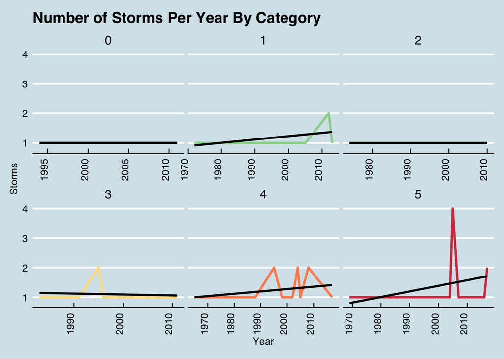

Lets see the trend in the hurricane over the years

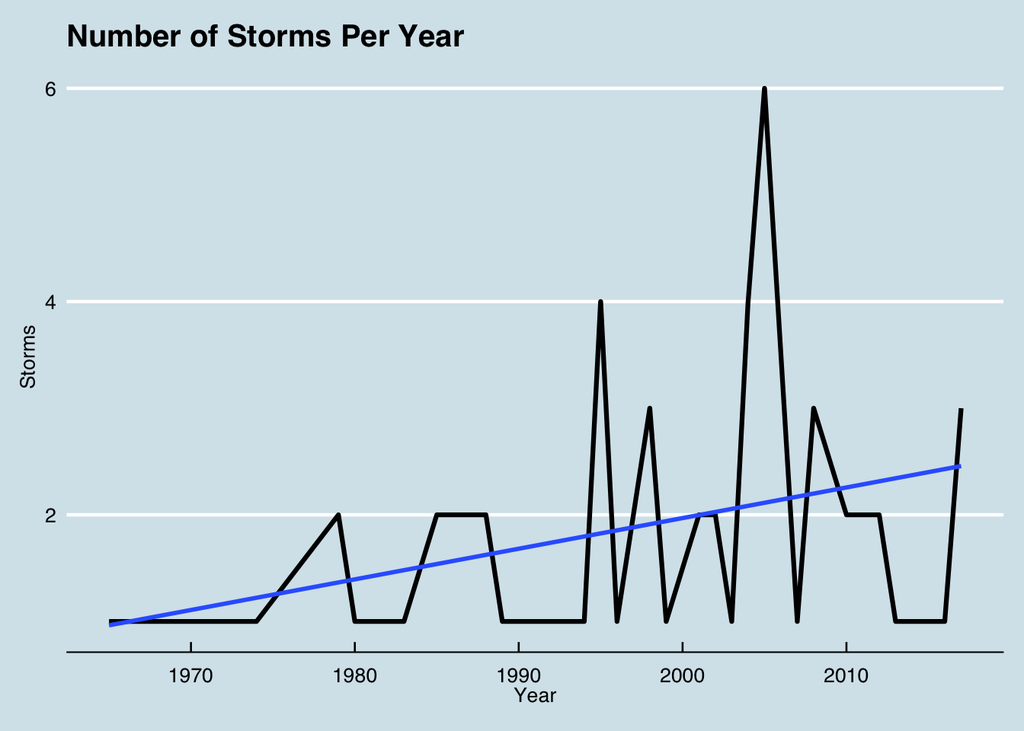

There is an upward trend in the number of storms over time.

Lets see statistics of the damage caused by the hurricanes.

[output not shown]

Again, these numbers are in aggregate and may not tell the whole story. Dividing these into groups of storms is likely much more meaningful.

Lets see hurricanes of Category 3 or greater

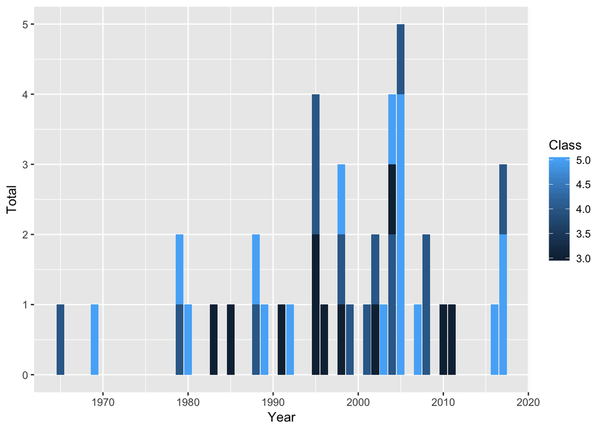

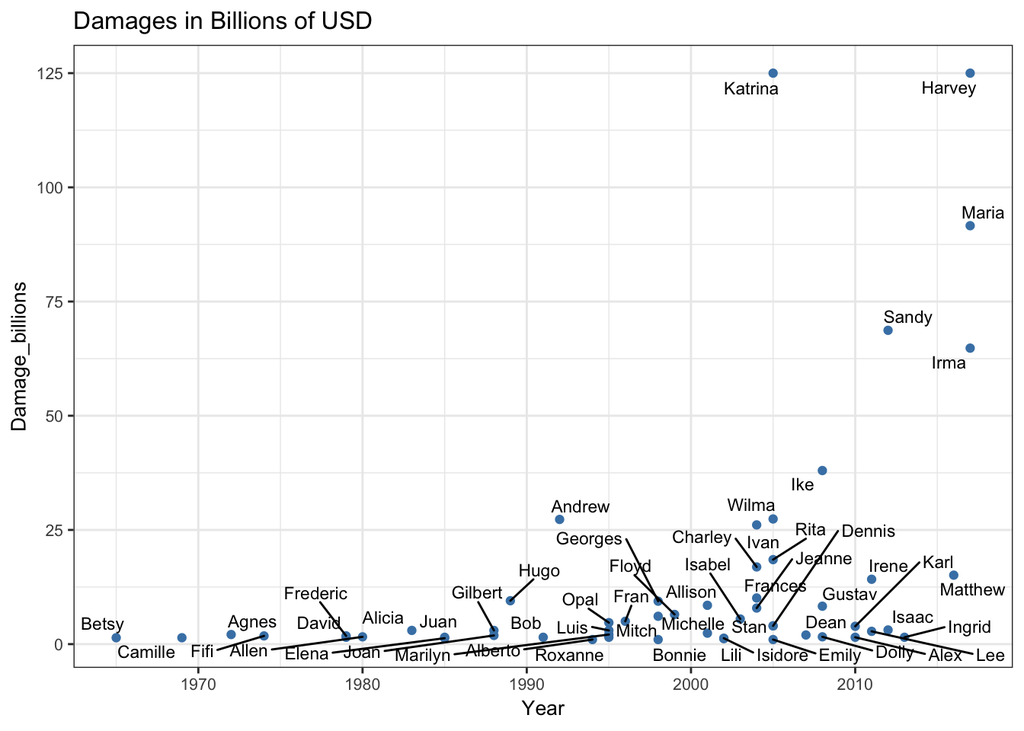

Lets see which storms might be the most deadly using the storm measurements highest wind speed recorded and lowest pressure recorded.

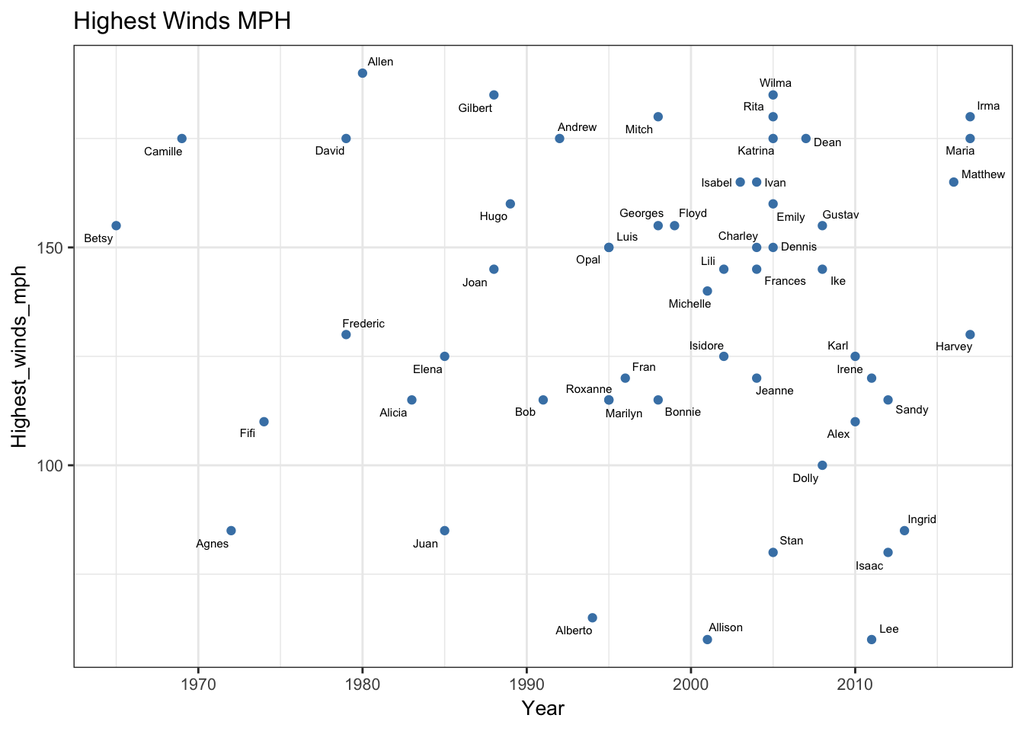

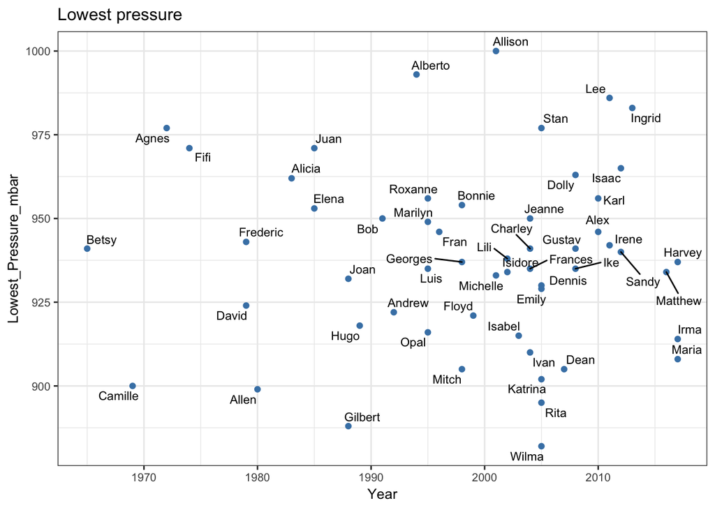

Fatalities caused due to low pressure

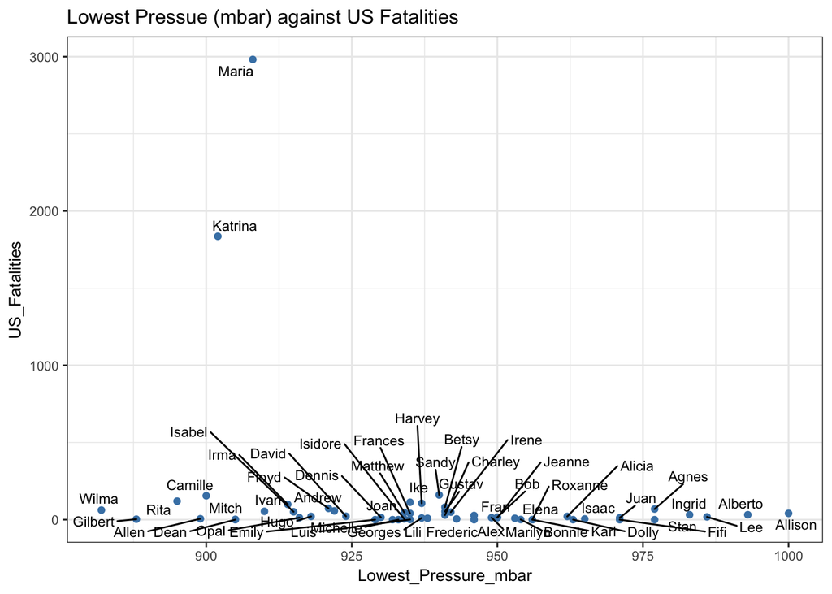

As we can see that Maria and Katrina are both on the higher end ofthe wind speed distribution and the lower end of the air pressure distribution, we can assert that a more powerful storm is a necessary component for the kind of death tolls associated with these storms.

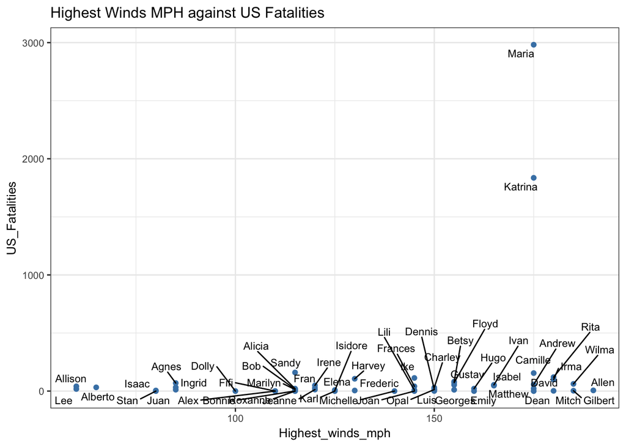

```
## # A tibble: 1 x 1
##   `sum(US_Fatalities)`
##                  <int>
## 1                 1773
```

Fatalities compared to top 5 US hurricanes Vs rest of the hurricanes.

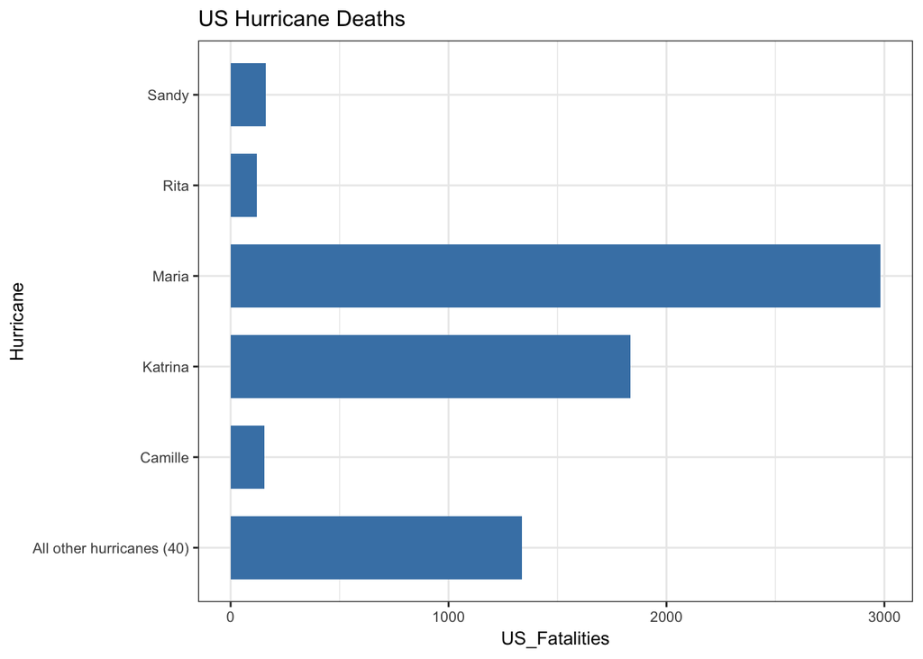

[figure not shown]

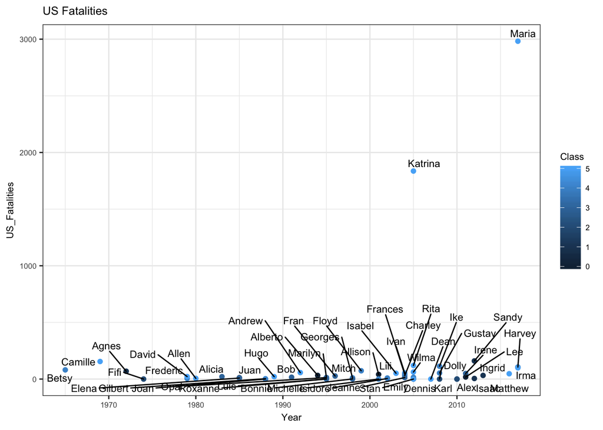

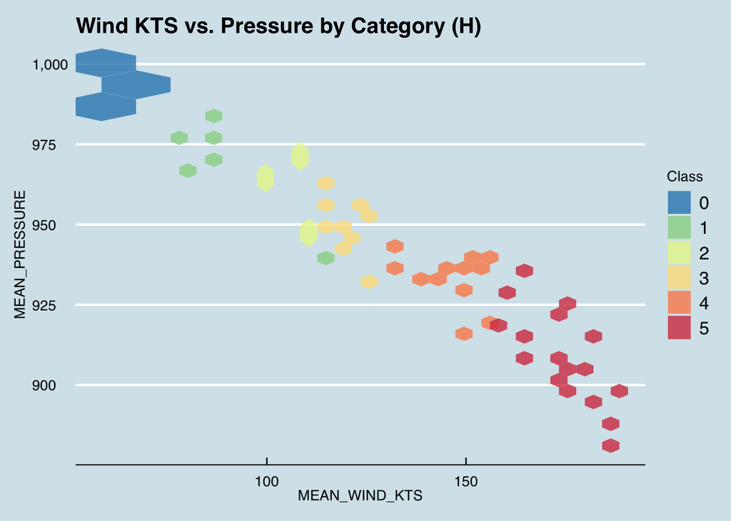

The code can be found in Github

**…To be continued**

I have done some basic EDA and identified some patterns in the data. While doing some EDA can simply be just for fun, in most data analysis, it’s important to find a place to apply these discoveries by making and testing hypotheses! There are plenty of industries where you could find a use for this:

- Flood Insurance - improve statistical modeling and risk analysis
- Land Development - identify safe location
- Planning the infrastucture projects near the coast